```python
import pandas as pd
import numpy as np
import matplotlib.pyplot as plt
```

# 1

## 1.1

Given that X is 3x2, beta is 2x1, y is (1, 2, 3).T

X @ beta should be 3x1

y - X @ beta should be 3x1 as well

So (y - X @ beta).T is in 1x3

Therefore (y - X @ beta).T @ (y - X @ beta) should be 1x3 @ 3x1 = 1x1, which is a scalar

## 1.2

From tehe previous problem, we have (y - X @ beta) in 3x1

X.T should be in 2x3

So X.T @ (y - X @ beta) = 2x1

2x1 times a scaler would still be 2x1

## 1.3

```python
np.random.seed(371)
y = np.array([[1], [2], [3]])
X = np.random.normal(size=(3, 2))

def f(beta):
    return (y - X @ beta).T @ (y - X @ beta)

def grad(beta):
    return -2 * X.T @ (y - X @ beta)
```

## 1.4

```python
def showF(f, grad = None,
        levels = (0.5, 2, 8, 21, 44),
        x1range = (-5, 5), x2range=(-5, 5)):
    nGrid = 26
    ex1 = np.linspace(x1range[0], x1range[1], nGrid)
    ex2 = np.linspace(x2range[0], x2range[1], nGrid)
    (xm1, xm2) = np.meshgrid(ex1, ex2)
    x1 = xm1.ravel()
    1
    x2 = xm2.ravel()
    z = np.zeros_like(xm1)
    g1 = np.zeros_like(xm1)
    g2 = np.zeros_like(xm1)
    for i in range(nGrid):
        for j in range(nGrid):
            x = np.array([[xm1[i,j]], [xm2[i,j]]])
            z[i,j] = f(x)[0,0]
            if grad is not None:
                g = grad(x)
                g1[i,j] = g[0,0]
                g2[i,j] = g[1,0]
    fig = plt.figure()
    ax = fig.add_subplot(111)
    ax.set_aspect('equal')
    cs = ax.contour(ex1, ex2, z, levels = levels)
    ax.clabel(cs, inline=1, fontsize=10)
    ax.quiver(ex1, ex2, g1, g2, width=0.002, headwidth=5)
    ## Print suggested levels, in case it is hard to know what is good
    print("Suggested levels:")
    print(np.percentile(z, (20, 40, 60, 80)))
    return ax
```

```
Suggested levels:
[ 26.20867274  45.71960112  69.83525982 106.12803436]
```

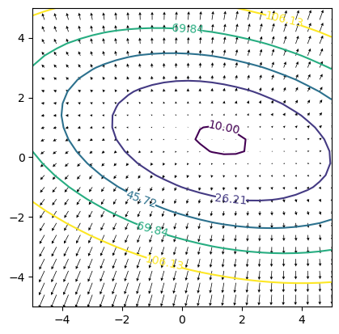

```python
showF(
    f,
    grad,
    levels=(10, 26.20867274, 45.71960112, 69.83525982, 106.12803436),
    x1range=(-5, 5),
    x2range=(-5, 5),
)
```

## 1.5

```
Suggested levels:
[ 32.96 128.   284.48 543.2 ]
```

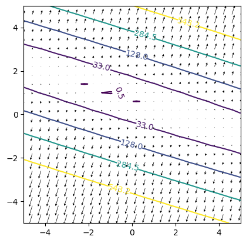

```python
X = np.array([[1, 2], [1, 3], [1, 4]])
showF(
    f,
    grad,
    levels=(0.5, 32.96, 128, 284.48, 543.2),
    x1range=(-5, 5),
    x2range=(-5, 5),
)
```

The minimum is approximately (-1, 1)

```
Suggested levels:
[ 16.48562  55.32978 133.32242 268.86738]
```

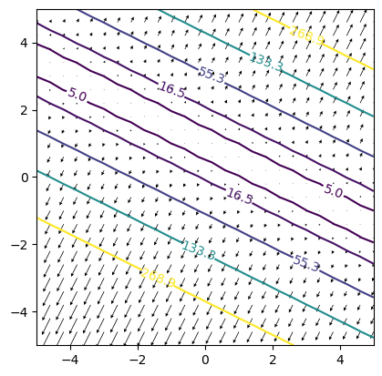

```python
X = np.array([[1, 2], [1, 2.01], [1, 2.02]])
showF(
    f,
    grad,
    levels=(5, 16.48562, 55.32978, 133.32242, 268.86738),
    x1range=(-5, 5),
    x2range=(-5, 5),
)
```

The second one is hard to tell probably (0, 1)

The first one has some circular contours at the center, which is easier to find the minimum.

The second countour is thin which is pretty hard to find a minimum visually.

# 2

## 2.1

- a

Minimum occur when first derivative = 0

$$ f'(x) = 2x = 0 $$

$$ x = 0 $$

- b

From previous problem $$ \nabla f(x) = \frac{d}{dx}(x^2) = 2x $$

x is a scalar, so gradient vector is 1-D

- c

Initial value $x^0 = 1$

$R = 0.1$

$$ \nabla f(x_0) = \frac{d}{dx}(x_0^2) = 2x_0 = 2 $$

- d

$$ x_1 = x_0 - R \nabla f(x_0) $$

$$ x_1 = 1 - 0.1 \cdot 2 = 0.8 $$

- e

We did move closer to the minimum

## 2.2

### 2.2.a

```python
epsilon = 0.01
R = 0.1
N = 100
x = 1
```

### 2.2.b

```python
def f(x):
    return x**2

def grad(x):
    return 2 * x
```

### 2.2.c

```python
def gd_1d(beta, f, grad, R, epsilon, N):
    x = beta
    fx = f(x)
    for i in range(N):
        gradient = grad(x)

        print(f"Iter {i}: x = {x:.4f}, f(x) = {fx:.4f}, grad = {gradient:.4f}")

        if abs(gradient) < epsilon:
            print(f"Converged after {i} iter")
            break

        x = x - R * gradient
    else:
        print(f"Did not converge in {N} iter")
    print(f"x = {x:.10f}")
```

```python
beta = 1
gd_1d(beta, f, grad, R, epsilon, N)
```

```
Iter 0: x = 1.0000, f(x) = 1.0000, grad = 2.0000
Iter 1: x = 0.8000, f(x) = 1.0000, grad = 1.6000
Iter 2: x = 0.6400, f(x) = 1.0000, grad = 1.2800
Iter 3: x = 0.5120, f(x) = 1.0000, grad = 1.0240
Iter 4: x = 0.4096, f(x) = 1.0000, grad = 0.8192
Iter 5: x = 0.3277, f(x) = 1.0000, grad = 0.6554
Iter 6: x = 0.2621, f(x) = 1.0000, grad = 0.5243
Iter 7: x = 0.2097, f(x) = 1.0000, grad = 0.4194
Iter 8: x = 0.1678, f(x) = 1.0000, grad = 0.3355
Iter 9: x = 0.1342, f(x) = 1.0000, grad = 0.2684
Iter 10: x = 0.1074, f(x) = 1.0000, grad = 0.2147
Iter 11: x = 0.0859, f(x) = 1.0000, grad = 0.1718
Iter 12: x = 0.0687, f(x) = 1.0000, grad = 0.1374
Iter 13: x = 0.0550, f(x) = 1.0000, grad = 0.1100
Iter 14: x = 0.0440, f(x) = 1.0000, grad = 0.0880
Iter 15: x = 0.0352, f(x) = 1.0000, grad = 0.0704
Iter 16: x = 0.0281, f(x) = 1.0000, grad = 0.0563
Iter 17: x = 0.0225, f(x) = 1.0000, grad = 0.0450
Iter 18: x = 0.0180, f(x) = 1.0000, grad = 0.0360
Iter 19: x = 0.0144, f(x) = 1.0000, grad = 0.0288
Iter 20: x = 0.0115, f(x) = 1.0000, grad = 0.0231
Iter 21: x = 0.0092, f(x) = 1.0000, grad = 0.0184
Iter 22: x = 0.0074, f(x) = 1.0000, grad = 0.0148
Iter 23: x = 0.0059, f(x) = 1.0000, grad = 0.0118
Iter 24: x = 0.0047, f(x) = 1.0000, grad = 0.0094
Converged after 24 iter
x = 0.0047223665
```

## 2.3

```python
experiments = [
    {"beta": 1.0, "R": 0.1, "epsilon": 0.01, "N": 10000},
    {"beta": 1.0, "R": 0.5, "epsilon": 0.01, "N": 10000},
    {"beta": 5, "R": 0.1, "epsilon": 0.01, "N": 10000},
    {"beta": 5, "R": 0.5, "epsilon": 0.01, "N": 10000},
]

for idx, exp in enumerate(experiments):
    print(f"Running Experiment {idx + 1}")
    gd_1d(beta=exp["beta"],
          f=f,
          grad=grad,
          R=exp["R"],
          epsilon=exp["epsilon"],
          N=exp["N"])
    print("=" * 50 + "\n")
```

```
Running Experiment 1
Iter 0: x = 1.0000, f(x) = 1.0000, grad = 2.0000
Iter 1: x = 0.8000, f(x) = 1.0000, grad = 1.6000
Iter 2: x = 0.6400, f(x) = 1.0000, grad = 1.2800
Iter 3: x = 0.5120, f(x) = 1.0000, grad = 1.0240
Iter 4: x = 0.4096, f(x) = 1.0000, grad = 0.8192
Iter 5: x = 0.3277, f(x) = 1.0000, grad = 0.6554
Iter 6: x = 0.2621, f(x) = 1.0000, grad = 0.5243
Iter 7: x = 0.2097, f(x) = 1.0000, grad = 0.4194
Iter 8: x = 0.1678, f(x) = 1.0000, grad = 0.3355
Iter 9: x = 0.1342, f(x) = 1.0000, grad = 0.2684
Iter 10: x = 0.1074, f(x) = 1.0000, grad = 0.2147
Iter 11: x = 0.0859, f(x) = 1.0000, grad = 0.1718
Iter 12: x = 0.0687, f(x) = 1.0000, grad = 0.1374
Iter 13: x = 0.0550, f(x) = 1.0000, grad = 0.1100
Iter 14: x = 0.0440, f(x) = 1.0000, grad = 0.0880
Iter 15: x = 0.0352, f(x) = 1.0000, grad = 0.0704
Iter 16: x = 0.0281, f(x) = 1.0000, grad = 0.0563
Iter 17: x = 0.0225, f(x) = 1.0000, grad = 0.0450
Iter 18: x = 0.0180, f(x) = 1.0000, grad = 0.0360
Iter 19: x = 0.0144, f(x) = 1.0000, grad = 0.0288
Iter 20: x = 0.0115, f(x) = 1.0000, grad = 0.0231
Iter 21: x = 0.0092, f(x) = 1.0000, grad = 0.0184
Iter 22: x = 0.0074, f(x) = 1.0000, grad = 0.0148
Iter 23: x = 0.0059, f(x) = 1.0000, grad = 0.0118
Iter 24: x = 0.0047, f(x) = 1.0000, grad = 0.0094
Converged after 24 iter
x = 0.0047223665
==================================================

Running Experiment 2
Iter 0: x = 1.0000, f(x) = 1.0000, grad = 2.0000
Iter 1: x = 0.0000, f(x) = 1.0000, grad = 0.0000
Converged after 1 iter
x = 0.0000000000
==================================================

Running Experiment 3
Iter 0: x = 5.0000, f(x) = 25.0000, grad = 10.0000
Iter 1: x = 4.0000, f(x) = 25.0000, grad = 8.0000
```

[output cut: 25 more lines]

```
Iter 27: x = 0.0121, f(x) = 25.0000, grad = 0.0242
Iter 28: x = 0.0097, f(x) = 25.0000, grad = 0.0193
Iter 29: x = 0.0077, f(x) = 25.0000, grad = 0.0155
Iter 30: x = 0.0062, f(x) = 25.0000, grad = 0.0124
Iter 31: x = 0.0050, f(x) = 25.0000, grad = 0.0099
Converged after 31 iter
x = 0.0049517602
==================================================

Running Experiment 4
Iter 0: x = 5.0000, f(x) = 25.0000, grad = 10.0000
Iter 1: x = 0.0000, f(x) = 25.0000, grad = 0.0000
Converged after 1 iter
x = 0.0000000000
==================================================
```

Finding Summary: In this case, all experiments are using the same smooth, convex, single minimum function. So that:

- When learning rate is large enough (but not too large), gradient descent can land very close to the minimum in just a few steps.
- When learning rate is small, the algorithm needs many more iterations to reach convergence.
- The initial value has less impact on convergence speed compared to the learning rate, because the function in this case is good.

# 3

## 3.1

Since A is symmetric by assumption, true minimum of f(x) occurs when gradient is 0. SO we have $2A \cdot x = 0$

$$ 2 \begin{pmatrix} 1 & 0 \\ 0 & 1 \end{pmatrix} \begin{pmatrix} x_1 \\ x_2 \end{pmatrix} = \begin{pmatrix} 0 \\ 0 \end{pmatrix} $$

$$ \begin{pmatrix} 2x_1 \\ 2x_2 \end{pmatrix} = \begin{pmatrix} 0 \\ 0 \end{pmatrix} $$

$$ x_1 = 0,\quad x_2 = 0 $$

True minimum occur when $x_1 = 0$ and $x_2 = 0$

## 3.2

```python
A = np.array([[1, 0], [0, 1]])

def f(x):
    return x.T @ A @ x
```

## 3.3

```python
def grad(x):
    return (A + A.T) @ x
```

## 3.4

```python
def gd_mult(beta, grad, R, epsilon, N):
    x = beta.copy()
    path = [x.copy()]
    for i in range(N):
        gradient = grad(x)
        if np.linalg.norm(gradient) < epsilon:
            print(f"Converged after {i} iterations")
            break
        x = x - R * gradient
        path.append(x.copy())
    else:
        print(f"Did not converge in {N} iterations")

    print("x =\n", x)
    return path
```

```python
beta = np.array([[2], [-3]])
R = 0.01
epsilon = 0.01
N = 1000
path = gd_mult(beta, grad, R, epsilon, N)
```

```
Converged after 326 iterations
x =
 [[ 0.00275887]
 [-0.0041383 ]]
```

## 3.6

```python
def showPath(
    f,
    grad,
    path,
    levels=(0.5, 2, 8, 21, 44),
    x1range=(-10, 5),
    x2range=(-10, 5),
):

    path_sampled = path[::5]
    if len(path_sampled) > 50:
        path_sampled = path_sampled[:50]
    if path[-1] is not path_sampled[-1]:
        path_sampled.append(path[-1])
    path_array = np.hstack(path_sampled)

    ax = showF(f, grad=grad, levels=levels, x1range=x1range, x2range=x2range)

    ax.plot(
        path_array[0],
        path_array[1],
        marker="o",
        color="blue",
        linewidth=1,
        markersize=2,
    )
    return ax
```

```
Converged after 30 iterations
x =
 [[ 0.00247588]
 [-0.00371382]]
Suggested levels:
[ 6.8  13.84 20.88 27.92]
```

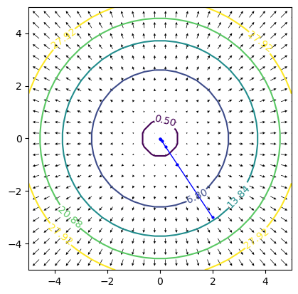

```python
beta = np.array([[2], [-3]])
path = gd_mult(beta, grad, R=0.1, epsilon=0.01, N=100000)

showPath(
    f,
    grad,
    path,
    levels=(0.5, 6.8, 13.84, 20.88, 27.92),
    x1range=(-5, 5),
    x2range=(-5, 5),
)

plt.show()
```

The gradient descent path follows a straight line toward the minimum at (0,0). The final value matches the theoretical minimum. This straight line path is expected because the function is symmetric, convex, and shaped like a single bowl. As a result, gradient descent converges smoothly.

## 3.7

```
Did not converge in 100000 iterations
x =
 [[nan]
 [nan]]
Suggested levels:
[  0.    15.36  45.92 106.08]
```

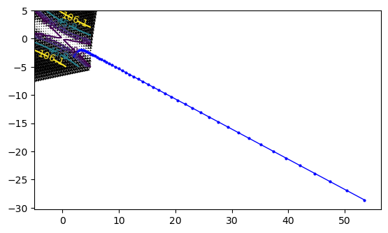

```python
A = np.array([[1, 3], [3, 5]])
beta = np.array([[2], [-3]])
path = gd_mult(beta,grad, R=0.01, epsilon=0.01, N=100000)

showPath(
    f, grad,
    path,
    levels=(0, 7, 15.36, 45.92, 106.08),
    x1range=(-5, 5), x2range=(-5, 5)
)
plt.show()
```

The shape of countours is in some hyperbolas with a saddle point. In this case, the path is not going to have a global minimum, it diverges and keep growing. The bahavior matches with the mathmatical analysis on eigenvalue below.

[figure not shown]

With the given condition above, we can't proceed Question 3.8.

Based on the discussion with Ott, he noticed that he put the wrong number. The correct matrix should be:

$$ A = \begin{pmatrix} 1 & 2 \\ 2 & 5 \end{pmatrix} $$

This matrix has positive eigenvalues, so theoretically it has a minimum. Therefore, Q3.8 will be based on the corrected matrix

## 3.8

```
Converged after 1348 iterations
x =
 [[ 0.02690298]
 [-0.01114358]]
Suggested levels:
[ 7.12 23.44 50.32 95.12]
```

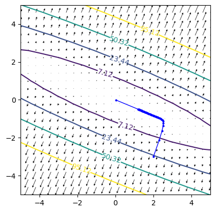

```python
A = np.array([[1, 2], [2, 5]])
beta = np.array([[2], [-3]])
path = gd_mult(beta, grad, R=0.01, epsilon=0.01, N=10000)

showPath(
    f,
    grad,
    path,
    levels=(0, 7.12, 23.44, 50.32, 95.12),
    x1range=(-5, 5),
    x2range=(-5, 5),
)
plt.show()
```

## 3.9

```python
A = np.arange(1, 26).reshape(5, 5)

A = 0.5 * (A + A.T) + 10 * np.eye(5)

x0 = np.array([[10], [20], [30], [40], [50]])

path = gd_mult(x0, grad, R=0.01, epsilon=0.01, N=100000)
```

```
Converged after 118 iterations
x =
 [[-0.00096769]
 [-0.00056793]
 [-0.00016818]
 [ 0.00023158]
 [ 0.00063134]]
```

# 4

```python
boston = pd.read_csv("../../data/boston.csv.bz2", sep="\t")
```

## 4.1

```python
y = np.array([[1], [2], [3]])
X = np.array([[1, 2], [1, 3], [1, 4]])
beta = np.zeros((2, 1))

def f(beta):
    return (y - X @ beta).T @ (y - X @ beta)

def grad(beta):
    return -2 * X.T @ (y - X @ beta)
```

## 4.2

```python
path = gd_mult(beta, grad, R=0.01, epsilon=0.01, N=10000)
```

```
Converged after 1021 iterations
x =
 [[-0.97477705]
 [ 0.99212094]]
```

Yes, I pretty much got similar result

## 4.3

```python
X_vars = ["rm", "lstat", "zn"]
X = boston[X_vars].to_numpy()
y = boston["medv"].values
X = np.column_stack((np.ones(X.shape[0]), X))
```

```python
# Reshape to one column, go and figure out how many rows
y = y.reshape(-1, 1)
y.shape
```

```
(506, 1)
```

X is 506x3. When we add a constant column, it becomes 506x4.

y is 506x1

We want to get a 4x1 result

So beta should be something in 4x1

We will initialize beta = 0

```python
def f(beta):
    diff = y - X @ beta
    return (diff.T @ diff).item()


def grad(beta):
    return -2 * X.T @ (y - X @ beta)
```

```python
def gd_adaptive(beta, f, grad, R_init=2e-6, epsilon=0.01, N=1000000):
    x = beta.copy()
    path = [x.copy()]
    R = R_init
    fx_prev = float(f(x))

    for i in range(N):
        gradient = grad(x)
        if np.linalg.norm(gradient) < epsilon:
            print(f"Converged after {i} iterations")
            break
        x_new = x - R * gradient
        fx_new = float(f(x_new))

        ## Correct Direction
        if fx_new < fx_prev:
            R *= 1.1
        ## Overshoot
        else:
            R /= 4
            continue

        x = x_new
        fx_prev = fx_new
        path.append(x.copy())

    else:
        print(f"Did not converge after {i} iterations")

    print("x =\n", x)
    return path
```

```python
beta = np.zeros((4, 1))
```

```python
path = gd_mult(
    beta,
    grad,
    R=2e-6,
    epsilon=0.01,
    N=1000000,
)
```

```
Converged after 597811 iterations
x =
 [[-1.45892096]
 [ 5.04531438]
 [-0.62402688]
 [ 0.01580765]]
```

## Extra

```python
path = gd_adaptive(beta, f, grad)
```

```
Converged after 294466 iterations
x =
 [[-1.4589212 ]
 [ 5.04531442]
 [-0.62402688]
 [ 0.01580765]]
```

While both of them provides the same result, regular gradient descent cost 597811 iteration, but adaptive gradient descent cost 294466 iterations. It indeed lead to a faster convergence.